# Analysis of willow leaf beetle system for github sharing

##### Visualization 01

```r
best_pop_model <- gls(candidate_formulas$pop_growth_1$m_mi,
                         data = beetle_summary_CAR1,
                         correlation = corCAR1(form = ~ time),
                         method = "REML",
                         na.action = na.omit)

spatial_pop_model <- gls(candidate_formulas$pop_growth_1$m_moran,
                         data = beetle_summary_CAR1,
                         correlation = corCAR1(form = ~ time),
                         method = "REML",
                         na.action = na.omit)

macro_pop_model <- gls(candidate_formulas$pop_growth_1$m_prev,
                         data = beetle_summary_CAR1,
                         correlation = corCAR1(form = ~ time),
                         method = "REML",
                         na.action = na.omit)

pred_df <- data.frame(
  obs = beetle_summary_CAR1$pop_growth_1,
  time = beetle_summary_CAR1$time,
  pred_mi = predict(best_pop_model, newdata = beetle_summary_CAR1),
  pred_mi_moran = predict(spatial_pop_model, newdata = beetle_summary_CAR1),
  pred_prev = predict(macro_pop_model, newdata = beetle_summary_CAR1)
)

pred_long <- rbind(
  data.frame(model = "best:mi", pred = pred_df$pred_mi, obs = pred_df$obs, time = pred_df$time),
  data.frame(model = "spatial alternative:moran", pred = pred_df$pred_mi_moran, obs = pred_df$obs, time = pred_df$time),
  data.frame(model = "macro only:prev", pred = pred_df$pred_prev, obs = pred_df$obs, time = pred_df$time)
)
```

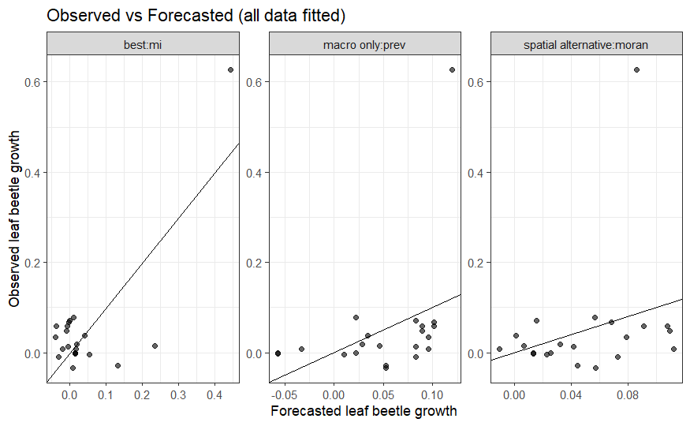

```r
ggplot(pred_long, aes(x = pred, y = obs)) +
  geom_point(alpha = 0.6) +
  geom_abline(slope = 1, intercept = 0) +
  facet_wrap(~ model, scales = "free") +
  labs(y = "Observed leaf beetle growth",
       x = "Forecasted leaf beetle growth",
       title = "Observed vs Forecasted (all data fitted)") +
  theme_bw() #3.5-6
```

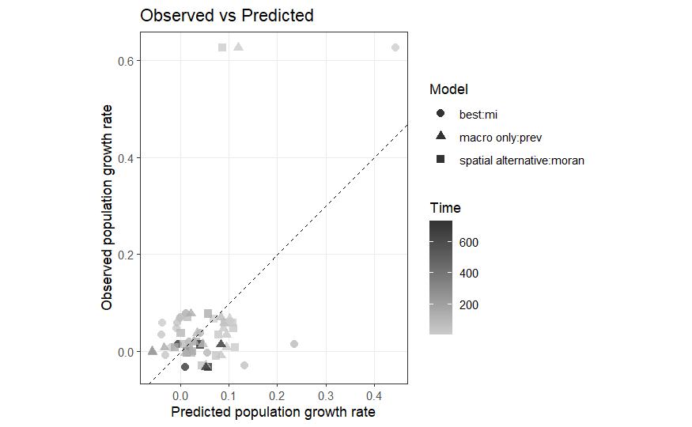

```r
ggplot(pred_long, aes(x = pred, y = obs,
                      shape = model,
                      color = time)) +
  geom_point(alpha = 0.8, size = 2.5) +
  geom_abline(slope = 1, intercept = 0,
              linetype = "dashed", color = "black") +
  coord_equal() +
  scale_color_gradient(
    low = "grey80",   # darker for earlier time
    high = "grey20"   # brighter for later time
  ) +
  labs(
    x = "Predicted population growth rate",
    y = "Observed population growth rate",
    color = "Time",
    shape = "Model",
    title = "Observed vs Predicted"
  ) +
  theme_bw() +
  theme(
    legend.position = "right",
    panel.grid.minor = element_blank()
  )
```

##### Visualization 02

- Comparing the error for each of 6 final time points

```r
b <- results_table$pop_growth_1[12, -c(1:12)]  # only macro
best <- results_table$pop_growth_1[1, -c(1:12)] # best model (mi)
alt  <- results_table$pop_growth_1[2, -c(1:12)] # alternative model (moran)

b_minus_best <- b - best
b_minus_alt <- b - alt

# converting long format
rep_name <- c("t = 154", "t = 219", "t = 226", "t = 723", "t = 730", "t = 747")
df_delta <- rbind(
  data.frame(rep = rep_name, del_RMSE = unlist(b_minus_best[1, ]), model = "Best:mi"),
  data.frame(rep = rep_name, del_RMSE = unlist(b_minus_alt[1, ]), model = "Alt_space:moran")
)
```

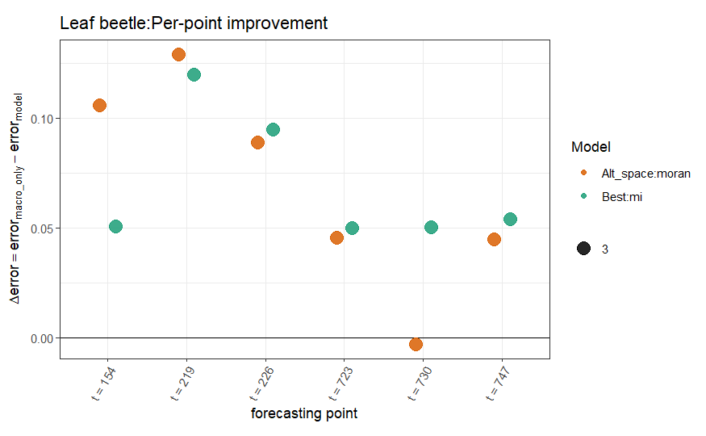

```r
ggplot(df_delta, aes(x = rep, y = del_RMSE, group = model)) +
  geom_hline(yintercept = 0) +
  geom_point(aes(size = 3, color = model), alpha = 0.85, position = position_dodge(width = 0.4)) +
  scale_color_manual(values = c("Best:mi" = "#1b9e77",
                                "Alt_space:moran" = "#d95f02"),
                     name = "Model") +
  labs(x = "forecasting point",
       y = expression(Delta*error == error[macro_only] - error[model]),
       size = NULL,
       title = "Leaf beetle:Per-point improvement") +
  theme_bw() +
  theme(axis.text.x = element_text(angle = 60, hjust = 1),
        aspect.ratio = 0.65
        ) # 5.0 - 4.0
```

##### Visualization 03

- Comparing the observed states and the forecasted from the rate for each of 6 final time points

```r
time_length <- 27
beetle_compare <- beetle_summary[1:time_length, c("time", "av_pop", "infestation_ratio")]

beetle_compare$pop_pred_best <- rep(NA, time_length)
beetle_compare$pop_pred_alt <- rep(NA, time_length)
beetle_compare$pop_pred_base <- rep(NA, time_length)

#model choice
best_model <- 1
alt_model <- 2
base_model <- 12

#specific for K = 6
K = 6
#starting point, identical to observation
beetle_compare$pop_pred_best[time_length - K] <- beetle_compare[time_length - K, "av_pop"]
beetle_compare$pop_pred_alt[time_length - K] <- beetle_compare[time_length - K, "av_pop"]
beetle_compare$pop_pred_base[time_length - K] <- beetle_compare[time_length - K, "av_pop"]

for(j in 1:6) {
  # time period
  delta_t <- beetle_compare[time_length - K + j, "time"] - beetle_compare[time_length - K + (j - 1), "time"]
  beetle_compare$pop_pred_best[time_length - K + j] <- beetle_compare[time_length - K + (j - 1), "av_pop"] * exp(results_table$pop_growth_1[best_model, 6 + j] * delta_t)
  beetle_compare$pop_pred_alt[time_length - K + j] <- beetle_compare[time_length - K + (j - 1), "av_pop"] * exp(results_table$pop_growth_1[alt_model, 6 + j] * delta_t)
  beetle_compare$pop_pred_base[time_length - K + j] <- beetle_compare[time_length - K + (j - 1), "av_pop"] * exp(results_table$pop_growth_1[base_model, 6 + j] * delta_t)
}
beetle_compare$pop_pred_best
```

```
 [1]           NA           NA           NA           NA           NA
 [6]           NA           NA           NA           NA           NA
[11]           NA           NA           NA           NA           NA
[16]           NA           NA           NA           NA           NA
[21] 6.666667e-01 7.144601e-01 5.164844e+00 2.125179e+00 1.602774e+04
[26] 5.393588e-01 3.526855e-01
```

```r
beetle_compare$pop_pred_alt
```

```
 [1]           NA           NA           NA           NA           NA
 [6]           NA           NA           NA           NA           NA
[11]           NA           NA           NA           NA           NA
[16]           NA           NA           NA           NA           NA
[21] 6.666667e-01 1.050799e+00 1.220679e+00 2.212542e+00 1.303645e+05
[26] 7.825246e-01 8.282320e-01
```

```r
beetle_compare$pop_pred_base
```

```
 [1]           NA           NA           NA           NA           NA
 [6]           NA           NA           NA           NA           NA
[11]           NA           NA           NA           NA           NA
[16]           NA           NA           NA           NA           NA
[21] 6.666667e-01 5.009188e-01 2.774933e-04 8.333686e-01 2.706428e-16
[26] 7.663776e-01 1.773481e+00
```

- Since the prediction at time point 25 was too large for the best model, it was excluded for the visualization

```r
beetle_summary$time[25]
```

```
[1] 723
```

```r
beetle_compare$pop_pred_best[25]
```

```
[1] 16027.74
```

```r
beetle_compare$pop_pred_best[25] <- NA
beetle_compare$pop_pred_alt[25]
```

```
[1] 130364.5
```

```r
beetle_compare$pop_pred_alt[25] <- NA
```

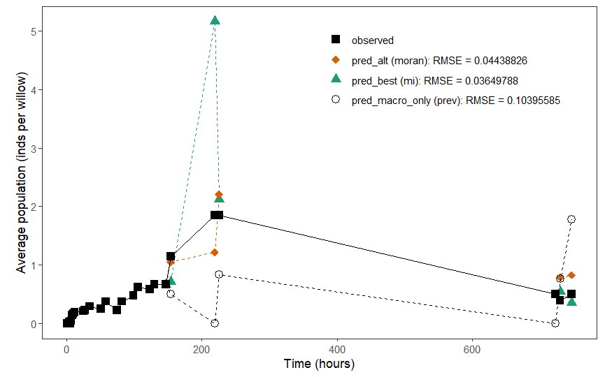

```r
ggplot(beetle_compare, aes(x = time)) +

  # pop_pred_best: dashed line + triangle

   geom_line(aes(y = pop_pred_best,
                 linetype = "pop_pred_best"), color = "#1b9e77") +
   geom_point(aes(y = pop_pred_best,
                  shape = "pred_best (mi): RMSE = 0.03649788"),
              color = "#1b9e77",
              size = 3) +

  geom_line(aes(y = pop_pred_alt,
                linetype = "pop_pred_alt"), color = "#d95f02") +
  geom_point(aes(y = pop_pred_alt,
                 shape = "pred_alt (moran): RMSE = 0.04438826"),
             color = "#d95f02",
             size = 3) +

  # pop_pred_base: dashed line + filled circle
  geom_line(aes(y = pop_pred_base,
                linetype = "pop_pred_macro_only"), color = "black") +
  geom_point(aes(y = pop_pred_base,
                 shape = "pred_macro_only (prev): RMSE = 0.10395585"),
             color = "black",
             size = 3) +

  # av_pop: solid line + filled rectangle
  geom_line(aes(y = av_pop, linetype = "observed"), color = "black") +
  geom_point(aes(y = av_pop, shape = "observed"),
             color = "black",
             size = 3) +

  scale_linetype_manual(
    values = c(
      "observed" = "solid",
      "pop_pred_best" = "dashed",
      "pop_pred_alt" = "dashed",
      "pop_pred_macro_only" = "dashed"
    )
  ) +

  scale_shape_manual(
    values = c(
      "observed" = 15,               # filled rectangle (largest)
      "pred_best (mi): RMSE = 0.03649788" = 17,    # filled triangle
      "pred_alt (moran): RMSE = 0.04438826" = 18,     # filled diamond
      "pred_macro_only (prev): RMSE = 0.10395585" = 1     # open circle
    )
  ) +

  scale_x_continuous(
    #trans = "log10",
    name = "Time (hours)",
  ) +

  scale_y_continuous(
    name = "Average population (inds per willow)",
  ) +

  labs(
    shape = NULL
  ) +

  guides(
    linetype = "none"
  ) +

  theme_minimal() +

  theme_bw() +
  theme(
    panel.grid = element_blank(),
    aspect.ratio = 0.6,
    legend.position = c(0.5, 0.95),
    legend.justification = c(0, 1)
    ) #4-4
```

#### [5.4] Prevalence growth rate 1 by continuous AR1 model

##### Analysis

```r
## =========================================================
## 2) DEFINE CANDIDATE MODELS (all subsets)
## =========================================================
# Model list as formulas; includes intercept-only baseline
candidate_formulas$prev_growth_1 <- list(
  m0 = as.formula("prev_growth_1 ~ 1"),
  m_pop = as.formula("prev_growth_1 ~ av_pop"),
  m_prev = as.formula("prev_growth_1 ~ infestation_ratio"),
  m_mi = as.formula("prev_growth_1 ~ smi"),
  m_LMX = as.formula("prev_growth_1 ~ LMX"),
  m_moran = as.formula("prev_growth_1 ~ moran"),
  m_pop_prev = as.formula("prev_growth_1 ~ av_pop + infestation_ratio"),
  m_pop_mi = as.formula("prev_growth_1 ~ av_pop + smi"),
  m_pop_LMX = as.formula("prev_growth_1 ~ av_pop + LMX"),
  m_pop_moran = as.formula("prev_growth_1 ~ av_pop + moran"),
  m_prev_mi = as.formula("prev_growth_1 ~ infestation_ratio + smi"),
  m_prev_LMX = as.formula("prev_growth_1 ~ infestation_ratio + LMX"),
  m_prev_LMX = as.formula("prev_growth_1 ~ infestation_ratio + moran"),
  m_mi_LMX = as.formula("prev_growth_1 ~ smi + LMX"),
  m_mi_moran = as.formula("prev_growth_1 ~ smi + moran"),
  m_moran_LMX = as.formula("prev_growth_1 ~ moran + LMX"),
  m_pop_prev_mi = as.formula("prev_growth_1 ~ av_pop + infestation_ratio + smi"),
  m_pop_prev_LMX = as.formula("prev_growth_1 ~ av_pop + infestation_ratio + LMX"),
  m_pop_prev_moran = as.formula("prev_growth_1 ~ av_pop + infestation_ratio + moran"),
  m_pop_mi_LMX = as.formula("prev_growth_1 ~ av_pop + smi + LMX"),
  m_prev_mi_LMX = as.formula("prev_growth_1 ~ infestation_ratio + smi + LMX"),
  m_pop_mi_moran = as.formula("prev_growth_1 ~ av_pop + smi + moran"),
  m_prev_mi_moran = as.formula("prev_growth_1 ~ infestation_ratio + smi + moran"),
  m_pop_moran_LMX = as.formula("prev_growth_1 ~ av_pop + moran + LMX"),
  m_prev_moran_LMX = as.formula("prev_growth_1 ~ infestation_ratio + moran + LMX"),
  m_mi_moran_LMX = as.formula("prev_growth_1 ~ smi + moran + LMX"),
  m_pop_prev_mi_LMX = as.formula("prev_growth_1 ~ av_pop + infestation_ratio + smi + LMX"),
  m_pop_prev_mi_moran = as.formula("prev_growth_1 ~ av_pop + infestation_ratio + smi + moran"),
  m_pop_prev_LMX_moran = as.formula("prev_growth_1 ~ av_pop + infestation_ratio + LMX + moran"),
  m_pop_mi_LMX_moran = as.formula("prev_growth_1 ~ av_pop + smi + LMX + moran"),
  m_prev_mi_LMX_moran = as.formula("prev_growth_1 ~ infestation_ratio + smi + LMX + moran"),
  m_all = as.formula("prev_growth_1 ~ av_pop + infestation_ratio + smi + LMX + moran")
)
```

```r
## =========================================================
## 3) Fit all models by ML for calculating AICc using all time points
## =========================================================
fits_gls$prev_growth_1 <- lapply(candidate_formulas$prev_growth_1, function(fm) {
  try(
    gls(fm,
        data = beetle_summary_CAR1,
        correlation = corCAR1(form = ~ time),
        method = "ML",
        na.action = na.omit),
    silent = TRUE
  )
})
#fits_gls$pop_growth_1

aicc_prev <- sapply(fits_gls$prev_growth_1, AICc)
```

```r
## =========================================================
## 4) Calculating RMSE by rolloing 1-step ahead by the last K time points
## =========================================================

results_temp_prev <- rolling_lastK_metrics(
  df = beetle_summary_CAR1,
  forms = candidate_formulas$prev_growth_1,
  K = 6,
  time_col = "time",
  y_col = "prev_growth_1"
  )
print(results_temp_prev)
```

|  | model | n_test | RMSE | MAE | pred1 | pred2 | pred3 | pred4 | pred5 | pred6 | e1 | e2 | e3 | e4 | e5 | e6 |
| --- | --- | --- | --- | --- | --- | --- | --- | --- | --- | --- | --- | --- | --- | --- | --- | --- |
| m0 | m0 | 6 | 0.05482148 | 0.04397270 | 0.0463659460 | 0.04708830 | 0.044443422 | 0.0419743426 | 0.03967314 | 0.0342215670 | 0.01155764 | 0.04496291 | 0.044443422 | 0.043722910 | 0.10903140 | 0.010117951 |
| m_pop | m_pop | 6 | 0.11679716 | 0.10191044 | -0.0576406645 | -0.14670711 | -0.173968496 | -0.0616108931 | 0.04241188 | 0.0428745858 | 0.11556425 | 0.14883250 | 0.173968496 | 0.059862326 | 0.11177014 | 0.001464932 |
| m_prev | m_prev | 6 | 0.08294828 | 0.07639876 | -0.0331456933 | -0.09658823 | -0.086820548 | -0.0557549625 | 0.04262573 | 0.0601382232 | 0.09106928 | 0.09871362 | 0.086820548 | 0.054006395 | 0.11198399 | 0.015798705 |
| m_mi | m_mi | 6 | 0.04514713 | 0.03939543 | 0.0177130583 | 0.02518808 | 0.022094504 | 0.0207770657 | 0.01527476 | 0.0004933325 | 0.04021053 | 0.02306269 | 0.022094504 | 0.022525633 | 0.08463301 | 0.043846185 |
| m_LMX | m_LMX | 6 | 0.05836217 | 0.04088408 | 0.0138290846 | -0.06671661 | 0.006478668 | 0.0029727260 | 0.04756492 | 0.0485843845 | 0.04409450 | 0.06884200 | 0.006478668 | 0.004721293 | 0.11692318 | 0.004244867 |
| m_moran | m_moran | 6 | 0.04856878 | 0.03117530 | 0.0455292820 | 0.00722544 | 0.020400761 | 0.0181750775 | 0.04430008 | 0.0287648250 | 0.01239430 | 0.00510005 | 0.020400761 | 0.019923645 | 0.11365834 | 0.015574693 |
| m_pop_prev | m_pop_prev | 6 | 0.08290801 | 0.07439889 | -0.0474483211 | -0.07356317 | 0.102375212 | 0.0113648305 | 0.04113865 | 0.0836868814 | 0.10537191 | 0.07568856 | 0.102375212 | 0.013113398 | 0.11049691 | 0.039347364 |
| m_pop_mi | m_pop_mi | 6 | 0.09220647 | 0.08549903 | -0.0587833616 | -0.10792475 | -0.120886054 | -0.0423588539 | 0.01789073 | 0.0068477672 | 0.11670695 | 0.11005014 | 0.120886054 | 0.040610287 | 0.08724899 | 0.037491751 |
| m_pop_LMX | m_pop_LMX | 6 | 0.13447477 | 0.11125505 | -0.0724859393 | -0.14592511 | -0.234325825 | -0.0370398784 | 0.04643346 | 0.0480009284 | 0.13040953 | 0.14805050 | 0.234325825 | 0.035291311 | 0.11579172 | 0.003661411 |
| m_pop_moran | m_pop_moran | 6 | 0.13320954 | 0.11485714 | -0.0995712245 | -0.15771598 | -0.201449741 | -0.0537886894 | 0.04376864 | 0.0391496198 | 0.15749481 | 0.15984137 | 0.201449741 | 0.052040122 | 0.11312690 | 0.005189898 |

[output cut: 22 more lines]

```r
## =========================================================
## 5) Summarize the results into the dataframe, ordering by RMSE
## =========================================================

results_table$prev_growth_1 <- data.frame(
  model = results_temp_prev$model,
  n_test = results_temp_prev$n_test,
  RMSE = results_temp_prev$RMSE,
  MAE = results_temp_prev$MAE,
  AICc = aicc_prev,
  delta = aicc_prev - min(aicc_prev),
  results_temp_prev[, -c(1:4)]   #for errors
)

results_table$prev_growth_1 <- results_table$prev_growth_1[order(results_table$prev_growth_1$RMSE), ]
print(results_table$prev_growth_1)
```

|  | model | n_test | RMSE | MAE | AICc | delta | pred1 | pred2 | pred3 | pred4 | pred5 | pred6 | e1 | e2 | e3 | e4 | e5 | e6 |
| --- | --- | --- | --- | --- | --- | --- | --- | --- | --- | --- | --- | --- | --- | --- | --- | --- | --- | --- |
| m_mi | m_mi | 6 | 0.04514713 | 0.03939543 | -39.68990 | 0.7029210 | 0.0177130583 | 0.02518808 | 0.022094504 | 0.0207770657 | 0.01527476 | 0.0004933325 | 0.04021053 | 0.02306269 | 0.022094504 | 0.022525633 | 0.08463301 | 0.043846185 |
| m_moran | m_moran | 6 | 0.04856878 | 0.03117530 | -26.00111 | 14.3917100 | 0.0455292820 | 0.00722544 | 0.020400761 | 0.0181750775 | 0.04430008 | 0.0287648250 | 0.01239430 | 0.00510005 | 0.020400761 | 0.019923645 | 0.11365834 | 0.015574693 |
| m_mi_moran | m_mi_moran | 6 | 0.04990237 | 0.04229797 | -39.74563 | 0.6471913 | 0.0143053624 | -0.04271746 | -0.013485407 | -0.0119111474 | 0.02027576 | -0.0077052393 | 0.04361822 | 0.04484285 | 0.013485407 | 0.010162580 | 0.08963402 | 0.052044757 |
| m0 | m0 | 6 | 0.05482148 | 0.04397270 | -28.05271 | 12.3401058 | 0.0463659460 | 0.04708830 | 0.044443422 | 0.0419743426 | 0.03967314 | 0.0342215670 | 0.01155764 | 0.04496291 | 0.044443422 | 0.043722910 | 0.10903140 | 0.010117951 |
| m_LMX | m_LMX | 6 | 0.05836217 | 0.04088408 | -26.84523 | 13.5475886 | 0.0138290846 | -0.06671661 | 0.006478668 | 0.0029727260 | 0.04756492 | 0.0485843845 | 0.04409450 | 0.06884200 | 0.006478668 | 0.004721293 | 0.11692318 | 0.004244867 |
| m_pop_prev_LMX | m_pop_prev_LMX | 6 | 0.06650395 | 0.05638740 | -22.89244 | 17.5003747 | -0.0420815420 | 0.04266610 | 0.021646878 | 0.0075704067 | 0.02859810 | 0.1131958533 | 0.10000513 | 0.04054071 | 0.021646878 | 0.009318974 | 0.09795636 | 0.068856335 |
| m_pop_mi_moran | m_pop_mi_moran | 6 | 0.07043341 | 0.06119022 | -35.74901 | 4.6438085 | -0.0429722238 | -0.08616861 | -0.029133961 | -0.0072053815 | 0.02013623 | -0.0095267161 | 0.10089581 | 0.08829400 | 0.029133961 | 0.005456814 | 0.08949449 | 0.053866234 |
| m_mi_LMX | m_mi_LMX | 6 | 0.07241089 | 0.06045503 | -40.39282 | 0.0000000 | -0.0261565697 | -0.11734129 | -0.019326853 | -0.0196335267 | 0.02314204 | 0.0148682977 | 0.08408016 | 0.11946668 | 0.019326853 | 0.017884960 | 0.09250030 | 0.029471220 |
| m_prev_mi_moran | m_prev_mi_moran | 6 | 0.08052740 | 0.07481637 | -36.26721 | 4.1256057 | -0.0608660033 | -0.09340573 | -0.068762149 | -0.0375683519 | 0.02023730 | 0.0039395238 | 0.11878959 | 0.09553112 | 0.068762149 | 0.035819785 | 0.08959556 | 0.040399994 |
| m_prev_mi | m_prev_mi | 6 | 0.08096821 | 0.07538700 | -39.73594 | 0.6568732 | -0.0520465798 | -0.09546705 | -0.082403361 | -0.0529114334 | 0.01885327 | 0.0213578775 | 0.10997017 | 0.09759244 | 0.082403361 | 0.051162866 | 0.08821153 | 0.022981640 |

[output cut: 22 more lines]

```r
## =========================================================
## 6) FINAL REFIT: refit the selected structure on ALL data by REML
##    and report coefficients + CI
## =========================================================
best_model_name$prev_growth_1 <- results_table$prev_growth_1$model[1]
best_formula$prev_growth_1 <- candidate_formulas$prev_growth_1[[best_model_name$prev_growth_1]]
final_fit$prev_growth_1 <- gls(best_formula$prev_growth_1,
                 data = beetle_summary_CAR1,
                 correlation = corCAR1(form = ~ time),
                 method = "REML",
                 na.action = na.omit)

cat("\nFinal model (REML) summary:\n")
```

```
Final model (REML) summary:
```

```r
print(summary(final_fit$prev_growth_1))
```

```
Generalized least squares fit by REML
  Model: best_formula$prev_growth_1
  Data: beetle_summary_CAR1
```

|  | AIC | BIC | logLik |
| --- | --- | --- | --- |
|  | -33.42755 | -29.64979 | 20.71377 |

```
Correlation Structure: Continuous AR(1)
 Formula: ~time
 Parameter estimate(s):
        Phi
5.73368e-05

Coefficients:
```

|  | Value | Std.Error | t-value | p-value |
| --- | --- | --- | --- | --- |
| (Intercept) | 0.2941917 | 0.06139872 | 4.791496 | 1e-04 |
| smi | -0.5478422 | 0.12467829 | -4.394046 | 3e-04 |

```
 Correlation:
    (Intr)
smi -0.962

Standardized residuals:
        Min          Q1         Med          Q3         Max
-2.06689953 -0.24668028 -0.06817411  0.56867621  1.92043940

Residual standard error: 0.07700428
Degrees of freedom: 21 total; 19 residual
```

```r
cat("\nFixed effects (tTable):\n")
```

```
Fixed effects (tTable):
```

```r
print(summary(final_fit$prev_growth_1)$tTable)
```

```
                 Value  Std.Error   t-value      p-value
(Intercept)  0.2941917 0.06139872  4.791496 0.0001268706
smi         -0.5478422 0.12467829 -4.394046 0.0003119141
```

##### Visualization 00

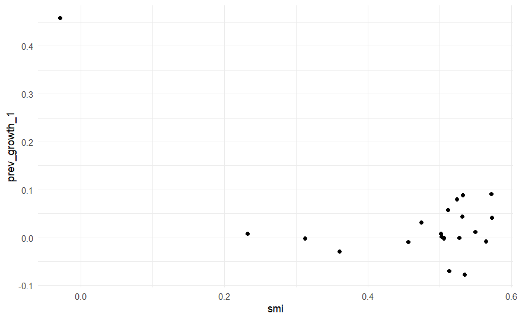

```r
ggplot(beetle_summary[1:27, ], aes(x = smi, y = prev_growth_1)) +
  geom_point() +
  #scale_y_log10() +
  theme_minimal()
```

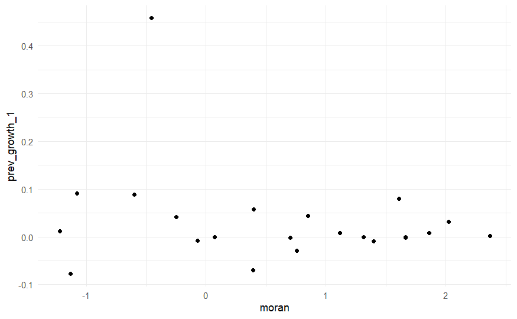

```r
ggplot(beetle_summary[1:27, ], aes(x = moran, y = prev_growth_1)) +
  geom_point() +
  #scale_y_log10() +
  theme_minimal()
```

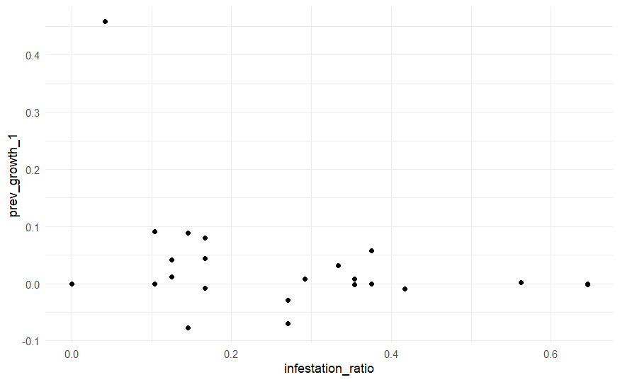

```r
ggplot(beetle_summary[1:27, ], aes(x = infestation_ratio, y = prev_growth_1)) +
  geom_point() +
  #scale_y_log10() +
  theme_minimal()
```

##### Visualization 01

```r
best_prev_model <- gls(candidate_formulas$prev_growth_1$m_mi,
                         data = beetle_summary_CAR1,
                         correlation = corCAR1(form = ~ time),
                         method = "REML",
                         na.action = na.omit)

spatial_prev_model <- gls(candidate_formulas$prev_growth_1$m_moran,
                         data = beetle_summary_CAR1,
                         correlation = corCAR1(form = ~ time),
                         method = "REML",
                         na.action = na.omit)

macro_prev_model <- gls(candidate_formulas$prev_growth_1$m_prev,
                         data = beetle_summary_CAR1,
                         correlation = corCAR1(form = ~ time),
                         method = "REML",
                         na.action = na.omit)

pred_df <- data.frame(
  obs = beetle_summary_CAR1$prev_growth_1,
  time = beetle_summary_CAR1$time,
  pred_mi = predict(best_prev_model, newdata = beetle_summary_CAR1),
  pred_mi_moran = predict(spatial_prev_model, newdata = beetle_summary_CAR1),
  pred_prev = predict(macro_prev_model, newdata = beetle_summary_CAR1)
)

pred_long <- rbind(
  data.frame(model = "best:mi", pred = pred_df$pred_mi, obs = pred_df$obs, time = pred_df$time),
  data.frame(model = "spatial alternative:moran", pred = pred_df$pred_mi_moran, obs = pred_df$obs, time = pred_df$time),
  data.frame(model = "macro only:prev", pred = pred_df$pred_prev, obs = pred_df$obs, time = pred_df$time)
)
```

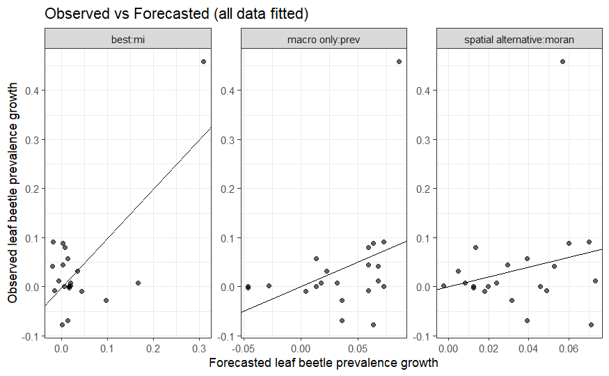

```r
ggplot(pred_long, aes(x = pred, y = obs)) +
  geom_point(alpha = 0.6) +
  geom_abline(slope = 1, intercept = 0) +
  facet_wrap(~ model, scales = "free") +
  labs(y = "Observed leaf beetle prevalence growth",
       x = "Forecasted leaf beetle prevalence growth",
       title = "Observed vs Forecasted (all data fitted)") +
  theme_bw()
```

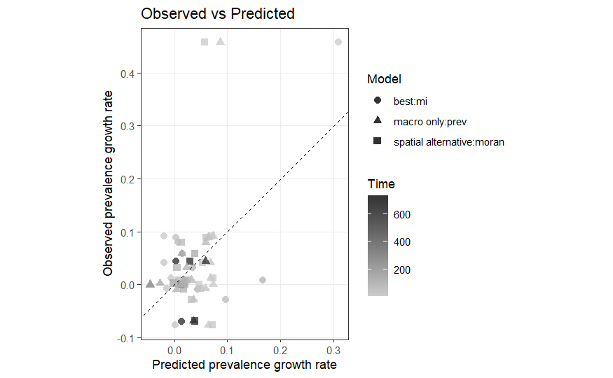

```r
ggplot(pred_long, aes(x = pred, y = obs,
                      shape = model,
                      color = time)) +
  geom_point(alpha = 0.8, size = 2.5) +
  geom_abline(slope = 1, intercept = 0,
              linetype = "dashed", color = "black") +
  coord_equal() +
  scale_color_gradient(
    low = "grey80",   # darker for earlier time
    high = "grey20"   # brighter for later time
  ) +
  labs(
    x = "Predicted prevalence growth rate",
    y = "Observed prevalence growth rate",
    color = "Time",
    shape = "Model",
    title = "Observed vs Predicted"
  ) +
  theme_bw() +
  theme(
    legend.position = "right",
    panel.grid.minor = element_blank()
  )
```

##### Visualization 02

- Comparing the error for each of 6 final time points

```r
b <- results_table$prev_growth_1[14, -c(1:12)]  # only macro
best <- results_table$prev_growth_1[1, -c(1:12)] # best model (mi)
alt  <- results_table$prev_growth_1[2, -c(1:12)] # alternative model (moran)

b_minus_best <- b - best
b_minus_alt <- b - alt

# converting long format
rep_name <- c("t = 154", "t = 219", "t = 226", "t = 723", "t = 730", "t = 747")
df_delta <- rbind(
  data.frame(rep = rep_name, del_RMSE = unlist(b_minus_best[1, ]), model = "Best"),
  data.frame(rep = rep_name, del_RMSE = unlist(b_minus_alt[1, ]), model = "Alt_space")
)
```

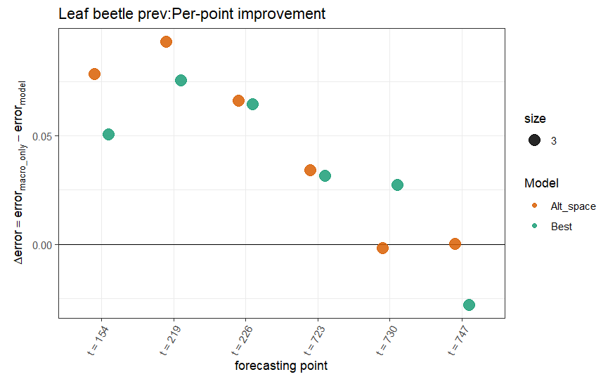

```r
ggplot(df_delta, aes(x = rep, y = del_RMSE, group = model)) +
  geom_hline(yintercept = 0) +
  geom_point(aes(size = 3, color = model), alpha = 0.85, position = position_dodge(width = 0.4)) +
  scale_color_manual(values = c("Best" = "#1b9e77",
                                "Alt_space" = "#d95f02"),
                     name = "Model") +
  labs(x = "forecasting point", y = expression(Delta*error == error[macro_only] - error[model]),
       title = "Leaf beetle prev:Per-point improvement") +
  theme_bw() +
  theme(axis.text.x = element_text(angle = 60, hjust = 1),
        aspect.ratio = 0.65
        )
```

##### Visualization 03

- Comparing the observed states and the predicted from the rate for each of 6 final time points

```r
beetle_compare$prev_pred_best <- rep(NA, time_length)
beetle_compare$prev_pred_alt <- rep(NA, time_length)
beetle_compare$prev_pred_base <- rep(NA, time_length)

#model choice
best_model <- 1
alt_model <- 2
base_model <- 14

#specific for K = 6
K = 6
#starting point, identical to observation
beetle_compare$prev_pred_best[time_length - K] <- beetle_compare[time_length - K, "infestation_ratio"]
beetle_compare$prev_pred_alt[time_length - K] <- beetle_compare[time_length - K, "infestation_ratio"]
beetle_compare$prev_pred_base[time_length - K] <- beetle_compare[time_length - K, "infestation_ratio"]

for(j in 1:6) {
  # time period
  delta_t <- beetle_compare[time_length - K + j, "time"] - beetle_compare[time_length - K + (j - 1), "time"]
  beetle_compare$prev_pred_best[time_length - K + j] <- beetle_compare[time_length - K + (j - 1), "infestation_ratio"] * exp(results_table$prev_growth_1[best_model, 6 + j] * delta_t)
  beetle_compare$prev_pred_alt[time_length - K + j] <- beetle_compare[time_length - K + (j - 1), "infestation_ratio"] * exp(results_table$prev_growth_1[alt_model, 6 + j] * delta_t)
  beetle_compare$prev_pred_base[time_length - K + j] <- beetle_compare[time_length - K + (j - 1), "infestation_ratio"] * exp(results_table$prev_growth_1[base_model, 6 + j] * delta_t)
}
beetle_compare$prev_pred_best
```

```
 [1]           NA           NA           NA           NA           NA
 [6]           NA           NA           NA           NA           NA
[11]           NA           NA           NA           NA           NA
[16]           NA           NA           NA           NA           NA
[21] 3.750000e-01 4.245023e-01 2.891748e+00 7.538572e-01 1.971210e+04
[26] 3.013966e-01 1.680703e-01
```

```r
beetle_compare$prev_pred_alt
```

```
 [1]           NA           NA           NA           NA           NA
 [6]           NA           NA           NA           NA           NA
[11]           NA           NA           NA           NA           NA
[16]           NA           NA           NA           NA           NA
[21]    0.3750000    0.5157546    0.8996850    0.7449721 5408.8927984
[26]    0.3692981    0.2717813
```

```r
beetle_compare$prev_pred_base
```

```
 [1]           NA           NA           NA           NA           NA
 [6]           NA           NA           NA           NA           NA
[11]           NA           NA           NA           NA           NA
[16]           NA           NA           NA           NA           NA
[21] 3.750000e-01 2.973489e-01 1.055649e-03 3.517067e-01 5.966593e-13
[26] 3.649950e-01 4.632865e-01
```

– Again, exclude the outlier for the visualization

```r
beetle_summary$time[25]
```

```
[1] 723
```

```r
beetle_compare$prev_pred_best[25]
```

```
[1] 19712.1
```

```r
beetle_compare$prev_pred_best[25] <- NA
beetle_compare$prev_pred_alt[25]
```

```
[1] 5408.893
```

```r
beetle_compare$prev_pred_alt[25] <- NA
```

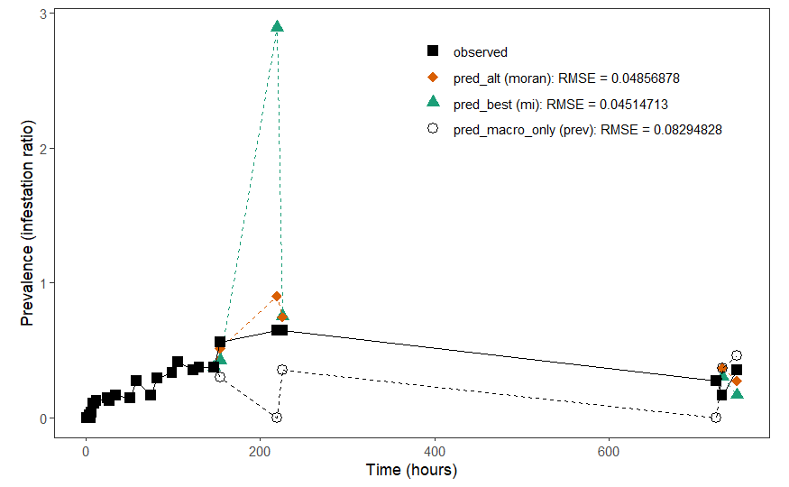

```r
ggplot(beetle_compare, aes(x = time)) +

  # pop_pred_best: dashed line + triangle
  geom_line(aes(y = prev_pred_best,
                linetype = "prev_pred_best"), color = "#1b9e77") +
  geom_point(aes(y = prev_pred_best,
                 shape = "pred_best (mi): RMSE = 0.04514713"),
             color = "#1b9e77",
             size = 3) +

  geom_line(aes(y = prev_pred_alt,
                linetype = "prev_pred_alt"), color = "#d95f02") +
  geom_point(aes(y = prev_pred_alt,
                 shape = "pred_alt (moran): RMSE = 0.04856878"),
             color = "#d95f02",
             size = 3) +

  # pop_pred_base: dashed line + filled circle
  geom_line(aes(y = prev_pred_base,
                linetype = "prev_pred_macro_only"), color = "black") +
  geom_point(aes(y = prev_pred_base,
                 shape = "pred_macro_only (prev): RMSE = 0.08294828"),
             color = "black",
             size = 3) +

  # av_pop: solid line + filled rectangle
  geom_line(aes(y = infestation_ratio, linetype = "observed"), color = "black") +
  geom_point(aes(y = infestation_ratio, shape = "observed"),
             color = "black",
             size = 3) +

  scale_linetype_manual(
    values = c(
      "observed" = "solid",
      "prev_pred_best" = "dashed",
      "prev_pred_alt" = "dashed",
      "prev_pred_macro_only" = "dashed"
    )
  ) +

  scale_shape_manual(
    values = c(
      "observed" = 15,               # filled rectangle (largest)
      "pred_best (mi): RMSE = 0.04514713" = 17,    # filled triangle
      "pred_alt (moran): RMSE = 0.04856878" = 18,     # filled diamond
      "pred_macro_only (prev): RMSE = 0.08294828" = 1     # open circle
    )
  ) +

  scale_x_continuous(
    name = "Time (hours)",
  ) +

  scale_y_continuous(
    name = "Prevalence (infestation ratio)",
  ) +

  labs(
    shape = NULL
  ) +

  guides(
    linetype = "none"
  ) +

  theme_bw() +
  theme(
    panel.grid = element_blank(),
    aspect.ratio = 0.6,
    legend.position = c(0.5, 0.95),
    legend.justification = c(0, 1)
    )
```

– Save some objects for the manuscript

```r
beetle_popl_growth_model <- best_formula$pop_growth_1
beetle_prev_growth_model <- best_formula$prev_growth_1
beetle_popl_growth_fitted <- final_fit$pop_growth_1
beetle_prev_growth_fitted <- final_fit$prev_growth_1

save(
  beetle_popl_growth_model,
  beetle_prev_growth_model,
  beetle_popl_growth_fitted,
  beetle_prev_growth_fitted,
  file = "beetle_bestfit.RData")
```